# ISA 365 Exam 1 Output Packet

Last complied on March 13, 2024

### Amazon Test

This past June Amazon performed a test on their image thumbnails. Instead of using traditional left aligned thumbnails, they shifted them below the main image and increased their size. They made this change on several items and measured purchase amount for the change over a week time period.

[figure not shown]

[figure not shown]

#### Summary

```r
head(df)
```

```
##   visit_id user_spend variant
## 1    63531          0       A
## 2    41550          0       A
## 3    24814          0       A
## 4     6375          0       A
## 5    44724          0       A
## 6     8790          0       A
```

```
## # A tibble: 2 × 4
##   variant  mean    sd count
##   <chr>   <dbl> <dbl> <int>
## 1 A        5.89  18.4  3401
## 2 B        4.71  15.3  3426
```

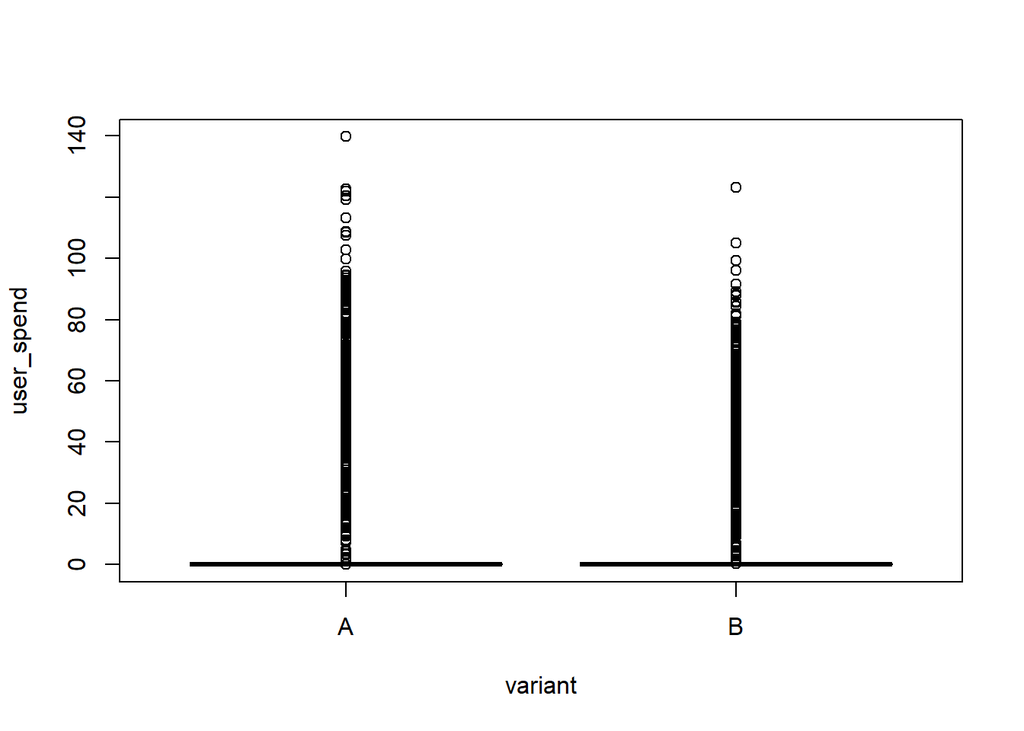

```r
boxplot(user_spend~variant, data=df)
```

#### Analysis

```r
t.test(user_spend~variant, data=df)
```

```
##
##  Welch Two Sample t-test
##
## data:  user_spend by variant
## t = 2.8771, df = 6578.2, p-value = 0.004026
## alternative hypothesis: true difference in means between group A and group B is not equal to 0
## 95 percent confidence interval:
##  0.3757793 1.9827520
## sample estimates:
## mean in group A mean in group B
##        5.893840        4.714574
```

For variant A:

```r
5.893840+qnorm(0.975)+18.4/sqrt(3401)
```

```
## [1] 8.169315
```

```r
5.893840-qnorm(0.975)+18.4/sqrt(3401)
```

```
## [1] 4.249387
```

For variant A:

```r
5.893840+qt(0.975, 3400)+18.4/sqrt(3401)
```

```
## [1] 8.170013
```

```r
5.893840-qt(0.975, 3400)+18.4/sqrt(3401)
```

```
## [1] 4.248689
```

For variant A:

```r
5.893840+qnorm(0.95)+18.4/sqrt(3401)
```

```
## [1] 7.854205
```

```r
5.893840-qnorm(0.95)+18.4/sqrt(3401)
```

```
## [1] 4.564497
```

For variant A:

```r
5.893840+qt(0.95, 3400)+18.4/sqrt(3401)
```

```
## [1] 7.854653
```

```r
5.893840-qt(0.95, 3400)+18.4/sqrt(3401)
```

```
## [1] 4.564049
```

### Walmart Tests

Walmart ran an A/B test where they added a “popular picks” badge to certain items (not sure about the logic for adding a badge to certain products and not others). Other products ended up with “best seller” badges. They measured the purchase rate of the items over a two week period.

#### Preliminaries

First the Analysts at Walmart completed a preliminary sample size study. They were interested in finding a difference in purchase rates of 5%. Their current purchase rate is 3.45%

```r
power.t.test(n=NULL, sig.level = 0.05, power=0.8, delta = 0.05)
```

```
##
##      Two-sample t test power calculation
##
##               n = 6280.064
##           delta = 0.05
##              sd = 1
##       sig.level = 0.05
##           power = 0.8
##     alternative = two.sided
##
## NOTE: n is number in *each* group
```

```r
power.prop.test(n=NULL, sig.level = 0.05, power=0.8, p1=0.0345, p2=0.036225)
```

```
##
##      Two-sample comparison of proportions power calculation
##
##               n = 179954.9
##              p1 = 0.0345
##              p2 = 0.036225
##       sig.level = 0.05
##           power = 0.8
##     alternative = two.sided
##
## NOTE: n is number in *each* group
```

[figure not shown]

[figure not shown]

#### Summary

```r
head(df)
```

```
##   variant purchase
## 1       a        0
## 2       a        0
## 3       a        0
## 4       a        0
## 5       a        0
## 6       a        0
```

```r
df %>% group_by(variant) %>% summarise("mean"=mean(purchase), "sd"=sd(purchase), "count"=n())
```

```
## # A tibble: 2 × 4
##   variant   mean    sd count
##   <chr>    <dbl> <dbl> <int>
## 1 a       0.0293 0.169  5014
## 2 b       0.0209 0.143  4971
```

```r
df %>% group_by(variant, purchase) %>%  summarise(n = n()) %>%
  mutate(freq = n / sum(n))
```

```
## # A tibble: 4 × 4
## # Groups:   variant [2]
##   variant purchase     n   freq
##   <chr>      <int> <int>  <dbl>
## 1 a              0  4867 0.971
## 2 a              1   147 0.0293
## 3 b              0  4867 0.979
## 4 b              1   104 0.0209
```

#### Analysis

```r
t.test(df$purchase~df$variant)
```

```
##
##  Welch Two Sample t-test
##
## data:  df$purchase by df$variant
## t = 2.6824, df = 9750.4, p-value = 0.007322
## alternative hypothesis: true difference in means between group a and group b is not equal to 0
## 95 percent confidence interval:
##  0.002260657 0.014532476
## sample estimates:
## mean in group a mean in group b
##      0.02931791      0.02092134
```

```r
prop.test(x=c(147, 104), n=c(5014,4971))
```

```
##
##  2-sample test for equality of proportions with continuity correction
##
## data:  c(147, 104) out of c(5014, 4971)
## X-squared = 6.8429, df = 1, p-value = 0.008899
## alternative hypothesis: two.sided
## 95 percent confidence interval:
##  0.002061728 0.014731404
## sample estimates:
##     prop 1     prop 2
## 0.02931791 0.02092134
```

### Bol Test

Bol is a a leading online retailer in the Netherlands. They tested a smaller button with less padding against a slightly more bloated one. They measured the number of times the buttons were clicked.

[figure not shown]

[figure not shown]

#### Summary

```r
head(df)
```

```
##   variant click
## 1       a     0
## 2       a     0
## 3       a     0
## 4       a     0
## 5       a     0
## 6       a     0
```

```
## # A tibble: 4 × 4
## # Groups:   variant [2]
##   variant click     n   freq
##   <chr>   <int> <int>  <dbl>
## 1 a           0  1224 0.975
## 2 a           1    32 0.0255
## 3 b           0  1359 0.981
## 4 b           1    27 0.0195
```

#### Analysis

```r
iter=100000
a=32+1
b=1224+1
a1=27+1
b1=1359+1
count<-c()
for (i in 1:iter){
A<-rbeta(1, a, b)
B<-rbeta(1, a1, b1)
count[i]<-ifelse(A>B, 1, 0)


}
pdiff<-sum(count)/iter
pdiff
```

```
## [1] 0.84804
```

Individual intervals for variant A.

```r
a=32+1
b=1224+1
qbeta(0.975, a, b)
```

```
## [1] 0.03574949
```

```r
qbeta(0.025, a, b)
```

```
## [1] 0.01813871
```

```r
prop.test(x=32, n=1224)
```

```
##
##  1-sample proportions test with continuity correction
##
## data:  32 out of 1224, null probability 0.5
## X-squared = 1097.5, df = 1, p-value < 2.2e-16
## alternative hypothesis: true p is not equal to 0.5
## 95 percent confidence interval:
##  0.01823880 0.03714728
## sample estimates:
##          p
## 0.02614379
```

### Parachute Effectiveness Study

#### Random Sample from Population

```r
library(readxl)
df<-read_excel("I:\\Classes\\ISA 365\\Datasets\\class list.xlsx")
```

| Name |
| --- |
| Berry, Brooke |
| Clark, Melanie |
| Creedon, David |
| Cruise, Jack |
| Dittmann, Nathan |
| Edmondson, Rachel |

```r
set.seed(1234)
index<-sample(1:nrow(df),size=20)
index
```

```
##  [1] 28 22  9  5 38 16  4 34 39 70 26  6 15 14 52 58 65 55 21 40
```

#### Random Assignment

```r
study<-df[index,1]
treatment<-c(rep("parachute",10), rep("no parachute",10))
experiment<-data.frame(study, treatment)
```

| Name | treatment |
| --- | --- |
| Grisdale, Emma | parachute |
| Anderson, Preston | parachute |
| Gospodinov, Alexandra | parachute |
| Dittmann, Nathan | parachute |
| Orazen, Lilly | parachute |
| Roeseler, Noah | parachute |
| Cruise, Jack | parachute |
| Marchant, Evelyn | parachute |
| Padala, Anmol | parachute |
| Stuckey, Austin | parachute |
| Farmer, Benjamin | no parachute |
| Edmondson, Rachel | no parachute |
| Reasor, Berk | no parachute |
| Peeler, Sam | no parachute |
| Lamsettef, Malak | no parachute |
| Smith, Francis | no parachute |
| Kim, Donghyun | no parachute |
| Nunn, Kirk | no parachute |
| Afnan, Alex | no parachute |
| Pagel, Lauren | no parachute |